# ML1

2024-11-15

# Data Preprocessing

```
## [1] 508499     16
```

```
## spc_tbl_ [508,499 × 16] (S3: spec_tbl_df/tbl_df/tbl/data.frame)
##  $ SEX              : num [1:508499] 0 0 0 0 0 0 0 0 1 1 ...
##  $ INSR_BEGIN       : chr [1:508499] "08-AUG-17" "08-AUG-16" "08-AUG-15" "08-AUG-14" ...
##  $ INSR_END         : chr [1:508499] "07-AUG-18" "07-AUG-17" "07-AUG-16" "07-AUG-15" ...
##  $ EFFECTIVE_YR     : chr [1:508499] "08" "08" "08" "08" ...
##  $ INSR_TYPE        : num [1:508499] 1202 1202 1202 1202 1202 ...
##  $ INSURED_VALUE    : num [1:508499] 519755 519755 519755 519755 1400000 ...
##  $ PREMIUM          : num [1:508499] 5098 6557 6557 5103 13305 ...
##  $ OBJECT_ID        : num [1:508499] 5e+09 5e+09 5e+09 5e+09 5e+09 ...
##  $ PROD_YEAR        : num [1:508499] 2007 2007 2007 2007 2010 ...
##  $ SEATS_NUM        : num [1:508499] 4 4 4 4 4 4 4 4 0 0 ...
##  $ CARRYING_CAPACITY: chr [1:508499] "6" "6" "6" "6" ...
##  $ TYPE_VEHICLE     : chr [1:508499] "Pick-up" "Pick-up" "Pick-up" "Pick-up" ...
##  $ CCM_TON          : num [1:508499] 3153 3153 3153 3153 2494 ...
##  $ MAKE             : chr [1:508499] "NISSAN" "NISSAN" "NISSAN" "NISSAN" ...
##  $ USAGE            : chr [1:508499] "Own Goods" "Own Goods" "Own Goods" "Own Goods" ...
##  $ CLAIM_PAID       : num [1:508499] NA NA NA NA NA ...
##  - attr(*, "spec")=
##   .. cols(
##   ..   SEX = col_double(),
##   ..   INSR_BEGIN = col_character(),
##   ..   INSR_END = col_character(),
##   ..   EFFECTIVE_YR = col_character(),
##   ..   INSR_TYPE = col_double(),
##   ..   INSURED_VALUE = col_double(),
##   ..   PREMIUM = col_double(),
##   ..   OBJECT_ID = col_double(),
##   ..   PROD_YEAR = col_double(),
##   ..   SEATS_NUM = col_double(),
##   ..   CARRYING_CAPACITY = col_character(),
##   ..   TYPE_VEHICLE = col_character(),
##   ..   CCM_TON = col_double(),
##   ..   MAKE = col_character(),
##   ..   USAGE = col_character(),
##   ..   CLAIM_PAID = col_double()
##   .. )
##  - attr(*, "problems")=<externalptr>
```

```
## Anzahl der entfernten Duplikate: 113
```

```
##
## Legal entity         Male       Female
##       247026       217734        43626
```

[figure not shown]

```
## Fehlende Werte in INSURED_VALUE: 0
```

```
## Zusammenfassung der statistischen Kennzahlen von INSURED_VALUE:
```

```
##     Min.  1st Qu.   Median     Mean  3rd Qu.     Max.
##        0        0    62500   544064   800000 67824388
```

```
## Anzahl der Einträge mit dem Wert 0 in INSURED_VALUE: 181149
```

```
## Anzahl der Datensätze mit INSURED_VALUE = 0: 181149
```

```
## Verteilung der Versicherungstypen (INSR_TYPE) bei INSURED_VALUE = 0:
```

```
##
##               Private            Commercial Motor trade road risk
##                 92929                284178                   141
```

```
##
##               Private            Commercial Motor trade road risk
##                 35649                145462                    38
```

```
##
## Verteilung der Fahrzeugtypen (TYPE_VEHICLE) bei INSURED_VALUE = 0:
```

```
##
##                Automobile                       Bus               Motor-cycle
##                     25016                     23749                     73368
##                   Pick-up      Special construction           Station Wagones
##                     19747                      2397                      5183
##                    Tanker                   Tractor Trailers and semitrailers
##                      1377                       420                      2016
##                     Truck
##                     27876
```

```
##
## Verteilung der Fahrzeugnutzung (USAGE) bei INSURED_VALUE = 0:
```

```
##
##  Agricultural Any Farm  Agricultural Own Farm              Ambulance
##                    174                    341                    186
##              Car Hires Fare Paying Passengers          Fire fighting
##                    793                  53905                      6
##        General Cartage                Learnes                 Others
##                  24168                   1306                   4945
##              Own Goods            Own service                Private
##                  28565                   9290                  35736
##   Special Construction                   Taxi
##                   1493                  20241
```

```
##
## Zusammenfassung der Prämien (PREMIUM) bei INSURED_VALUE = 0:
```

```
##    Min. 1st Qu.  Median    Mean 3rd Qu.    Max.    NA's
##     0.0   347.7   647.4  1370.7  1830.5 33645.3       4
```

[figure not shown]

```
## Anzahl der verbleibenden Datensätze: 196099
```

[figure not shown]

```
## Zusammenfassung der statistischen Kennzahlen ohne 0-Werte:
```

```
##     Min.  1st Qu.   Median     Mean  3rd Qu.     Max.
##        1   397751   795000  1046650  1480050 67824388
```

[figure not shown]

```
##     Min.  1st Qu.   Median     Mean  3rd Qu.     Max.
##        1   397751   795000  1046650  1480050 67824388
```

```
##     Min.  1st Qu.   Median     Mean  3rd Qu.     Max.
##     2665   397751   795000  1046698  1480050 67824388
```

```
##   PREMIUM_0_Percent PREMIUM_NA_Percent PREMIUM_MORE_Percent
## 1            0.0031              0.002              99.9969
```

```
## Anzahl der entfernten Duplikate: 0
```

```
## Die OBJECT_IDs sind NICHT einmalig.
## Anzahl der Duplikate: 100652
## Durchschnittliche Häufigkeit der OBJECT_ID: 2.055
## Maximale Häufigkeit der OBJECT_ID: 8
## Durchschnittliche Häufigkeit der Kombination (OBJECT_ID, INSR_BEGIN, INSR_END, INSURED_VALUE, PREMIUM): 1
## Maximale Häufigkeit der Kombination (OBJECT_ID, INSR_BEGIN, INSR_END, INSURED_VALUE, PREMIUM): 2
```

```
##    Min. 1st Qu.  Median    Mean 3rd Qu.    Max.
##    1960    2003    2010    2007    2014    2018
```

```
##   SEATS_NUM_0 SEATS_NUM_NA SEATS_NUM_OTHER
## 1       19940           10          176087
```

```
##   SEATS_NUM_0_or_NA_Percent SEATS_NUM_OTHER_Percent
## 1                  10.17665                89.82335
```

```
##    Min. 1st Qu.  Median    Mean 3rd Qu.    Max.
##   0.000   1.000   4.000   6.086   4.000 198.000
```

```
##    Min. 1st Qu.  Median    Mean 3rd Qu.    Max.
##       0    1298    2779    3764    4200   19798
```

```
##   CCM_TON_0_Percent CCM_TON_MORE_Percent
## 1          13.76464             86.23536
```

```
##
##                Automobile                       Bus               Motor-cycle
##                       704                      2559                       678
##                   Pick-up      Special construction           Station Wagones
##                      1374                      1287                       598
##                    Tanker                   Tractor Trailers and semitrailers
##                       425                      3455                     13000
##                     Truck
##                      2902
```

```
##
##                Automobile                       Bus               Motor-cycle
##                     29028                     20034                     10267
##                   Pick-up      Special construction           Station Wagones
##                     45063                      2601                     21028
##                    Tanker                   Tractor Trailers and semitrailers
##                      2816                      1602                       816
##                     Truck
##                     35787
```

```
## Anzahl der entfernten Duplikate: 0
```

[output not shown]

[output cut: 946 more lines]

[output not shown]

```
##   CLAIM_PAID_0 CLAIM_PAID_MORE_THAN_0
## 1       125007                  20093
```

```
##   CLAIM_PAID_0_Percent CLAIM_PAID_MORE_THAN_0_Percent
## 1             86.15231                       13.84769
```

```
##   CLAIM_PAID_0 CLAIM_PAID_MORE_THAN_0
## 1       162658                  22489
```

```
##   CLAIM_PAID_0_Percent CLAIM_PAID_MORE_THAN_0_Percent
## 1             87.85344                       12.14656
```

```
##   CLAIM_PAID_0_Percent CLAIM_PAID_MORE_THAN_0_Percent
## 1             86.15231                       13.84769
```

```
##            SEX     INSR_BEGIN       INSR_END      INSR_TYPE  INSURED_VALUE
##              0              0              0              0              0
##        PREMIUM      OBJECT_ID      PROD_YEAR      SEATS_NUM   TYPE_VEHICLE
##              0              0              0              0              0
##        CCM_TON           MAKE          USAGE     CLAIM_PAID CLAIM_PAID_USD
##              0              0              0              0              0
##       DURATION   START_INS_YR
##              0              0
```

```
##                SEX         INSR_BEGIN           INSR_END          INSR_TYPE
##                  0                  0                  0                  0
##      INSURED_VALUE            PREMIUM          OBJECT_ID          SEATS_NUM
##                  0                  0                  0                  0
##       TYPE_VEHICLE            CCM_TON               MAKE              USAGE
##                  0                  0                  0                  0
##         CLAIM_PAID     CLAIM_PAID_USD           DURATION       START_INS_YR
##                  0                  0                  0                  0
##        AGE_VEHICLE AMOUNT_CLAIMS_PAID
##                  0                  0
```

# Graphical Data Analysis

First, the distribution of the individual numerical variables is analysed to determine whether any transformations are necessary.

[figure not shown]

The histograms show that the variables INSURED_VALUE, PREMIUM, CLAIM_PAID_USD and CCM_TON are right-skewed and require a log transformation. The transformed variables can be inserted in the later regression models instead of the original variables.

# Models

## Linear Model

A linear model is adapted, whereby CLAIM_PAID_USD_log was not included, as the premium is incurred at the start of the contract and this would therefore not make technical sense. Instead, a bonus-malus system is taken into account by adding AMOUNT_CLAIMS_PAID.

```
##
## Call:
## lm(formula = PREMIUM_log ~ SEX + INSR_TYPE + USAGE + TYPE_VEHICLE +
##     MAKE + AGE_VEHICLE + SEATS_NUM + CCM_TON_log + INSURED_VALUE_log +
##     AMOUNT_CLAIMS_PAID, data = clean_dat_motor)
##
## Residuals:
##     Min      1Q  Median      3Q     Max
## -4.0103 -0.1433  0.0632  0.2506  2.0985
##
## Coefficients:
##                                         Estimate Std. Error t value Pr(>|t|)
## (Intercept)                           -1.3149332  0.0561212 -23.430  < 2e-16
## SEXMale                               -0.0853692  0.0053558 -15.940  < 2e-16
## SEXFemale                             -0.0796192  0.0076065 -10.467  < 2e-16
## INSR_TYPEPrivate                       0.0886106  0.0200423   4.421 9.83e-06
## USAGECar Hires                        -0.2156283  0.0415019  -5.196 2.04e-07
## USAGEFare Paying Passengers            0.5417051  0.0291570  18.579  < 2e-16
## USAGEGeneral Cartage                   0.1532115  0.0496041   3.089  0.00201
## USAGEOwn Goods                        -0.5047742  0.0491266 -10.275  < 2e-16
## USAGEOwn service                      -0.0673302  0.0275711  -2.442  0.01461
## USAGEPrivate                          -0.4625354  0.0281823 -16.412  < 2e-16
## TYPE_VEHICLEBus                        0.1307061  0.0222932   5.863 4.56e-09
## TYPE_VEHICLEMotor-cycle               -0.0076512  0.0235611  -0.325  0.74538
## TYPE_VEHICLEPick-up                    0.0832227  0.0455400   1.827  0.06763
## TYPE_VEHICLESpecial construction       0.0108042  0.0417602   0.259  0.79585
## TYPE_VEHICLEStation Wagones            0.1688239  0.0075031  22.501  < 2e-16
## TYPE_VEHICLETanker                     0.3463080  0.0479742   7.219 5.29e-13
## TYPE_VEHICLETrailers and semitrailers  0.0638634  0.0642133   0.995  0.31996
## TYPE_VEHICLETruck                      0.3246406  0.0464155   6.994 2.68e-12
## MAKEDAEWOO                             0.1845153  0.0193497   9.536  < 2e-16
## MAKEFIAT                               0.1413248  0.0201080   7.028 2.10e-12
## MAKEFORD                               0.0950234  0.0171017   5.556 2.76e-08
## MAKEGEELY                              0.0994460  0.0234607   4.239 2.25e-05
## MAKEGENLYON                           -0.1549654  0.0299558  -5.173 2.31e-07
## MAKEHYUNDAI                            0.0521274  0.0167280   3.116  0.00183
## MAKEISUZU                              0.3090353  0.0130996  23.591  < 2e-16
## MAKEIVECO                             -0.0380251  0.0147388  -2.580  0.00988
## MAKELIFAN                              0.1311950  0.0175353   7.482 7.39e-14
## MAKEMAZDA                              0.0517023  0.0191657   2.698  0.00698
```

[output cut: 48 more lines]

```
## MAKESINO HOWO                         .
## MAKESUZUKI                            ***
## MAKETATA                              ***
## MAKETOYOTA                            ***
## AGE_VEHICLE                           ***
## SEATS_NUM                             ***
## CCM_TON_log                           *
## INSURED_VALUE_log                     ***
## AMOUNT_CLAIMS_PAID                    ***
## ---
## Signif. codes:  0 '***' 0.001 '**' 0.01 '*' 0.05 '.' 0.1 ' ' 1
##
## Residual standard error: 0.5036 on 99958 degrees of freedom
## Multiple R-squared:  0.7308, Adjusted R-squared:  0.7307
## F-statistic:  6619 on 41 and 99958 DF,  p-value: < 2.2e-16
```

```
## Single term deletions
##
## Model:
## PREMIUM_log ~ SEX + INSR_TYPE + USAGE + TYPE_VEHICLE + MAKE +
##     AGE_VEHICLE + SEATS_NUM + CCM_TON_log + INSURED_VALUE_log +
##     AMOUNT_CLAIMS_PAID
##                    Df Sum of Sq   RSS     AIC    F value    Pr(>F)
## <none>                          25348 -137161
## SEX                 2      68.8 25417 -136894   135.5764 < 2.2e-16 ***
## INSR_TYPE           1       5.0 25353 -137144    19.5468 9.827e-06 ***
## USAGE               6    2157.4 27506 -129005  1417.8731 < 2.2e-16 ***
## TYPE_VEHICLE        8     299.6 25648 -136002   147.6921 < 2.2e-16 ***
## MAKE               19     593.8 25942 -134884   123.2348 < 2.2e-16 ***
## AGE_VEHICLE         1      18.7 25367 -137089    73.6994 < 2.2e-16 ***
## SEATS_NUM           1      12.4 25361 -137114    49.0394 2.524e-12 ***
## CCM_TON_log         1       1.6 25350 -137157     6.2517   0.01241 *
## INSURED_VALUE_log   1   12108.2 37457  -98117 47746.8041 < 2.2e-16 ***
## AMOUNT_CLAIMS_PAID  1     206.3 25555 -136352   813.6607 < 2.2e-16 ***
## ---
## Signif. codes:  0 '***' 0.001 '**' 0.01 '*' 0.05 '.' 0.1 ' ' 1
```

```
##                           (Intercept)                               SEXMale
##                          -1.314933235                          -0.085369195
##                             SEXFemale                      INSR_TYPEPrivate
##                          -0.079619233                           0.088610579
##                        USAGECar Hires           USAGEFare Paying Passengers
##                          -0.215628313                           0.541705075
##                  USAGEGeneral Cartage                        USAGEOwn Goods
##                           0.153211453                          -0.504774189
##                      USAGEOwn service                          USAGEPrivate
##                          -0.067330170                          -0.462535383
##                       TYPE_VEHICLEBus               TYPE_VEHICLEMotor-cycle
##                           0.130706079                          -0.007651153
##                   TYPE_VEHICLEPick-up      TYPE_VEHICLESpecial construction
##                           0.083222728                           0.010804232
##           TYPE_VEHICLEStation Wagones                    TYPE_VEHICLETanker
##                           0.168823870                           0.346308019
## TYPE_VEHICLETrailers and semitrailers                     TYPE_VEHICLETruck
##                           0.063863449                           0.324640609
##                            MAKEDAEWOO                              MAKEFIAT
##                           0.184515271                           0.141324825
##                              MAKEFORD                             MAKEGEELY
##                           0.095023368                           0.099446048
##                           MAKEGENLYON                           MAKEHYUNDAI
##                          -0.154965367                           0.052127411
##                             MAKEISUZU                             MAKEIVECO
##                           0.309035283                          -0.038025106
##                             MAKELIFAN                             MAKEMAZDA
##                           0.131194965                           0.051702264
##                          MAKEMERCEDES                        MAKEMITSUBISHI
##                           0.196283343                           0.127393220
##                            MAKENISSAN                           MAKERENAULT
##                           0.147275719                          -0.098145229
##                              MAKESINO                         MAKESINO HOWO
##                          -0.011455266                           0.024377755
##                            MAKESUZUKI                              MAKETATA
##                           0.114685452                           0.149538684
##                            MAKETOYOTA                           AGE_VEHICLE
##                           0.161205353                           0.002944844
##                             SEATS_NUM                           CCM_TON_log
##                          -0.001751879                           0.010944818
##                     INSURED_VALUE_log                    AMOUNT_CLAIMS_PAID
##                           0.768206885                           0.136287464
```

[figure not shown]

```
## Mean Squared Error (MSE): 0.2534847
```

```
## R-squared: 0.7308074
```

The model summary shows that the Multiple R-squared value is 0.7308, indicating that the model can explain approximately 73.08% of the variance in premiums. This suggests that the model provides a good fit to the data. The F-test for the overall model is significant (p < 2.2e-16), indicating that the predictors as a group have a substantial effect on the premium.

All predictors have a significant impact on the target variable PREMIUM_log. For instance, the categories SEX and USAGE (usage) have a significant effect on PREMIUM_log. Men pay slightly less compared to women, while certain usages, such as “Fare Paying Passengers,” lead to higher premiums. In contrast, usages like “Own Goods” and “Private” are associated with lower premiums.

The coefficient of INSURED_VALUE_log (0.7682) in the model shows that the insured value of the vehicle has a strong influence on the premium level. Since both the insured value and the premium are logarithmically transformed, this means that a 1% increase in the insured value results in approximately a 0.7682% increase in the premium. This illustrates the direct and positive relationship between vehicle value and premium: higher-insured vehicles attract proportionally higher premiums, as they represent a greater financial risk for the insurer. Overall, this coefficient confirms that vehicle value is one of the most significant factors in premium calculation.

The coefficient of AMOUNT_CLAIMS_PAID, with a value of 0.1363, indicates that an increase in the number of claims leads to an increase in the log-transformed premium by approximately 0.1363. This means that each additional claim results in a proportional increase in the premium by about 13.63%. This coefficient highlights that an insured’s claim history has a significant impact on the premium level.

The coefficient of AGE_VEHICLE is 0.0029, indicating that with each additional year of vehicle age, the log-transformed premium increases by about 0.0029. Since the target variable is logarithmic, this implies that an additional year in vehicle age leads to a minimal increase in the premium of approximately 0.29%.

The coefficient of SEATS_NUM is -0.00175, which means that with each additional seat, the log-transformed premium decreases by approximately 0.00175. Given the logarithmic nature of the target variable, this can be interpreted as each additional seat leading to a slight reduction in the premium by around 0.175%.

VIF: An analysis of multicollinearity revealed that the Variance Inflation Factor (VIF) for the variable INSR_TYPE is 5.85, which suggests possible multicollinearity. This could affect the model’s stability and interpretability and should be considered in further model optimization.

Residuals Analysis Residuals vs. Fitted Plot: The Residuals vs. Fitted Plot displays a funnel-shaped pattern, indicating heteroskedasticity. The variance of the residuals increases with higher predicted values, meaning that the model is less accurate for larger premium values. This violates the assumption of constant variance, suggesting that homoskedasticity is not fully met.

Normal Q-Q Plot: The Normal Q-Q Plot shows that the residuals do not lie perfectly along the line, indicating significant deviations from the theoretical normal distribution, particularly at the tails. These “heavy tails” suggest a non-normal distribution of residuals, potentially due to outliers or unmodeled non-linear relationships.

To improve the model, various measures could be considered. One approach would be to transform the target variable, for example, using a Box-Cox transformation, to reduce heteroskedasticity and achieve a more stable residual variance. Additionally, incorporating non-linear relationships by including polynomial terms or using a generalized linear model (GLM) could be beneficial. This would allow the model to better capture complex relationships between variables, thereby enhancing predictive accuracy.

## Poisson

First, the data is grouped accordingly, and the results are analyzed to gather insights.

```
##    Min. 1st Qu.  Median    Mean 3rd Qu.    Max.
##  0.0000  0.0000  0.0000  0.1791  0.0000 46.0000
```

[figure not shown]

```
## [1] 0.1790586
```

```
## [1] 0.3650433
```

The analysis of the distribution of the target variable AMOUNT_CLAIMS reveals that a large portion of the values are zero. This concentration of zero values is confirmed by the median, as well as the 1st and 3rd quartiles, which are also at zero. Additionally, the distribution shows some high outliers with a maximum value of 46, indicating an uneven distribution with a few high values. The low mean of 0.1791 further supports this observation, suggesting a significant number of zero values.Given these distribution characteristics, the use of a Zero-Inflated Poisson (ZIP) model could be appropriate, as such a model can account for both random and structural zeros. Initially, however, a Poisson model will be fitted.

```
##
## Call:
## glm(formula = AMOUNT_CLAIMS ~ SEX + INSR_TYPE + TYPE_VEHICLE +
##     MAKE + AGE_VEHICLE + SEATS_NUM + CCM_TON + INSURED_VALUE +
##     PREMIUM, family = poisson(link = "log"), data = dat_amount_claims)
##
## Coefficients:
##                                         Estimate Std. Error z value Pr(>|z|)
## (Intercept)                           -1.200e+00  9.032e-02 -13.281  < 2e-16
## SEXMale                               -4.059e-01  2.468e-02 -16.449  < 2e-16
## SEXFemale                             -4.728e-01  3.972e-02 -11.903  < 2e-16
## INSR_TYPEPrivate                       2.501e-01  6.834e-02   3.659 0.000253
## TYPE_VEHICLEBus                       -1.671e-01  7.769e-02  -2.151 0.031503
## TYPE_VEHICLEMotor-cycle               -3.240e+00  4.601e-01  -7.042 1.89e-12
## TYPE_VEHICLEPick-up                    1.139e-01  7.331e-02   1.554 0.120126
## TYPE_VEHICLESpecial construction       8.007e-02  1.939e-01   0.413 0.679604
## TYPE_VEHICLEStation Wagones           -3.233e-01  3.645e-02  -8.869  < 2e-16
## TYPE_VEHICLETanker                    -4.640e-01  1.250e-01  -3.712 0.000206
## TYPE_VEHICLETrailers and semitrailers -5.598e-01  3.283e-01  -1.705 0.088183
## TYPE_VEHICLETruck                      4.702e-02  9.021e-02   0.521 0.602217
## MAKEDAEWOO                            -7.534e-01  1.033e-01  -7.294 3.00e-13
## MAKEFIAT                              -7.671e-01  1.269e-01  -6.045 1.49e-09
## MAKEFORD                              -2.683e-01  8.605e-02  -3.118 0.001823
## MAKEGEELY                              3.922e-02  1.052e-01   0.373 0.709333
## MAKEGENLYON                           -7.784e-01  1.571e-01  -4.955 7.25e-07
## MAKEHYUNDAI                           -3.562e-01  8.916e-02  -3.995 6.46e-05
## MAKEISUZU                             -5.545e-01  6.277e-02  -8.833  < 2e-16
## MAKEIVECO                             -7.208e-01  7.584e-02  -9.504  < 2e-16
## MAKELIFAN                             -2.035e-01  8.220e-02  -2.475 0.013308
## MAKEMAZDA                             -4.090e-02  8.634e-02  -0.474 0.635671
## MAKEMERCEDES                          -9.091e-01  1.053e-01  -8.631  < 2e-16
## MAKEMITSUBISHI                        -4.308e-01  6.630e-02  -6.497 8.20e-11
## MAKENISSAN                            -2.715e-01  5.849e-02  -4.643 3.44e-06
## MAKERENAULT                           -3.912e-01  1.498e-01  -2.611 0.009027
## MAKESINO                              -5.413e-01  1.328e-01  -4.077 4.56e-05
## MAKESINO HOWO                         -9.059e-01  7.570e-02 -11.967  < 2e-16
## MAKESUZUKI                            -6.848e-01  1.443e-01  -4.745 2.09e-06
## MAKETATA                              -1.079e+00  1.247e-01  -8.650  < 2e-16
## MAKETOYOTA                            -1.417e-01  5.122e-02  -2.766 0.005673
## AGE_VEHICLE                           -4.480e-02  1.804e-03 -24.843  < 2e-16
```

[output cut: 36 more lines]

```
## AGE_VEHICLE                           ***
## SEATS_NUM                             ***
## CCM_TON                               ***
## INSURED_VALUE                         ***
## PREMIUM                               ***
## ---
## Signif. codes:  0 '***' 0.001 '**' 0.01 '*' 0.05 '.' 0.1 ' ' 1
##
## (Dispersion parameter for poisson family taken to be 1)
##
##     Null deviance: 56192  on 77186  degrees of freedom
## Residual deviance: 53113  on 77151  degrees of freedom
## AIC: 77497
##
## Number of Fisher Scoring iterations: 7
```

```
##                           (Intercept)                               SEXMale
##                         -1.199531e+00                         -4.059098e-01
##                             SEXFemale                      INSR_TYPEPrivate
##                         -4.727981e-01                          2.500586e-01
##                       TYPE_VEHICLEBus               TYPE_VEHICLEMotor-cycle
##                         -1.670950e-01                         -3.240007e+00
##                   TYPE_VEHICLEPick-up      TYPE_VEHICLESpecial construction
##                          1.139349e-01                          8.006750e-02
##           TYPE_VEHICLEStation Wagones                    TYPE_VEHICLETanker
##                         -3.232992e-01                         -4.640321e-01
## TYPE_VEHICLETrailers and semitrailers                     TYPE_VEHICLETruck
##                         -5.597884e-01                          4.701695e-02
##                            MAKEDAEWOO                              MAKEFIAT
##                         -7.534160e-01                         -7.671059e-01
##                              MAKEFORD                             MAKEGEELY
##                         -2.682717e-01                          3.921656e-02
##                           MAKEGENLYON                           MAKEHYUNDAI
##                         -7.784331e-01                         -3.562094e-01
##                             MAKEISUZU                             MAKEIVECO
##                         -5.544635e-01                         -7.208167e-01
##                             MAKELIFAN                             MAKEMAZDA
##                         -2.034788e-01                         -4.090397e-02
##                          MAKEMERCEDES                        MAKEMITSUBISHI
##                         -9.090543e-01                         -4.307733e-01
##                            MAKENISSAN                           MAKERENAULT
##                         -2.715283e-01                         -3.911515e-01
##                              MAKESINO                         MAKESINO HOWO
##                         -5.412876e-01                         -9.059321e-01
##                            MAKESUZUKI                              MAKETATA
##                         -6.847925e-01                         -1.078515e+00
##                            MAKETOYOTA                           AGE_VEHICLE
##                         -1.416733e-01                         -4.480383e-02
##                             SEATS_NUM                               CCM_TON
##                          8.747609e-03                          3.124821e-05
##                         INSURED_VALUE                               PREMIUM
##                         -1.384306e-07                          1.894822e-05
```

```
##                           (Intercept)                               SEXMale
##                            0.30133547                            0.66637028
##                             SEXFemale                      INSR_TYPEPrivate
##                            0.62325590                            1.28410071
##                       TYPE_VEHICLEBus               TYPE_VEHICLEMotor-cycle
##                            0.84611923                            0.03916362
##                   TYPE_VEHICLEPick-up      TYPE_VEHICLESpecial construction
##                            1.12067918                            1.08336020
##           TYPE_VEHICLEStation Wagones                    TYPE_VEHICLETanker
##                            0.72375725                            0.62874336
## TYPE_VEHICLETrailers and semitrailers                     TYPE_VEHICLETruck
##                            0.57132996                            1.04813977
##                            MAKEDAEWOO                              MAKEFIAT
##                            0.47075570                            0.46435500
##                              MAKEFORD                             MAKEGEELY
##                            0.76470002                            1.03999568
##                           MAKEGENLYON                           MAKEHYUNDAI
##                            0.45912487                            0.70032593
##                             MAKEISUZU                             MAKEIVECO
##                            0.57438032                            0.48635487
##                             MAKELIFAN                             MAKEMAZDA
##                            0.81588754                            0.95992131
##                          MAKEMERCEDES                        MAKEMITSUBISHI
##                            0.40290508                            0.65000623
##                            MAKENISSAN                           MAKERENAULT
##                            0.76221367                            0.67627769
##                              MAKESINO                         MAKESINO HOWO
##                            0.58199841                            0.40416499
##                            MAKESUZUKI                              MAKETATA
##                            0.50419482                            0.34010015
##                            MAKETOYOTA                           AGE_VEHICLE
##                            0.86790475                            0.95618504
##                             SEATS_NUM                               CCM_TON
##                            1.00878598                            1.00003125
##                         INSURED_VALUE                               PREMIUM
##                            0.99999986                            1.00001895
```

```
## Overdispersion ratio (Deviance / DF): 0.6884257
```

```
## Goodness-of-Fit p-value: 1
```

```
## Variance Inflation Factor (VIF) values for all predictor variables:
```

```
##                     GVIF Df GVIF^(1/(2*Df))
## SEX             1.624635  2        1.128987
## INSR_TYPE      14.051227  1        3.748497
## TYPE_VEHICLE  276.509321  8        1.421042
## MAKE           16.507471 19        1.076575
## AGE_VEHICLE     1.888760  1        1.374322
## SEATS_NUM       2.739027  1        1.655001
## CCM_TON         5.312166  1        2.304814
## INSURED_VALUE   3.556136  1        1.885772
## PREMIUM         2.909685  1        1.705780
```

[figure not shown]

The analysis of the Poisson model for predicting claim frequency indicated no overdispersion. The calculated overdispersion value, represented by the ratio of deviance to degrees of freedom, is 0.688, which is significantly below 1. This suggests that the model does not overestimate variance in the data, and overdispersion is not an issue. The Goodness-of-Fit test further confirms the adequacy of the model, as the p-value of 1 supports the null hypothesis that the model sufficiently describes the data.

The Poisson regression model for predicting the number of claims reveals that several variables show statistically significant relationships with claim frequency. The model indicates statistically significant differences in claim frequency across categories (p-value < 0.001). The group of legal entities, which serves as the reference category, exhibits the highest claim rate. Compared to legal entities, males have a rate ratio of 0.666, reflecting a 33.4% lower claim rate, while females have the lowest claim frequency, with a rate ratio of 0.623, or 37.7% below that of legal entities.

For the insurance type (INSR_TYPE), it was found that INSR_TYPEPrivate has a rate ratio of 1.284, indicating that private insurers have a 28.4% higher claim probability compared to the reference category INSR_TYPECommercial. The variables TYPE_VEHICLE and MAKE also show significant differences in claim rates. Among vehicle types, Pick-up has the highest claim rate, with a rate ratio of 1.121, representing a 12.1% increase in claim probability compared to the reference category Automobile; however, this effect is not statistically significant (p-value = 0.120). Conversely, Motor-cycle has the lowest claim rate, with a rate ratio of 0.039, indicating an approximately 96% reduced claim probability and a highly significant result (p-value < 0.001).

Further analysis indicates that vehicle age (AGE_VEHICLE) has a rate ratio of 0.956, meaning that the claim rate decreases by approximately 4.4% with each additional year (p-value < 0.001). The number of seats (SEATS_NUM) shows a rate ratio of 1.009, indicating that each additional seat slightly increases the claim probability, though significantly. Engine capacity (CCM_TON) shows no practical change in claim rate with a rate ratio of 1.000031, though it is statistically significant (p-value < 0.001). Insured value (INSURED_VALUE) has a rate ratio of 0.99999986, effectively showing no influence on claim frequency, although the effect is statistically significant. Premium amount (PREMIUM) exhibits a rate ratio of 1.000019, suggesting a minimal increase in claim probability with rising premiums; again, the effect is significant but very small.

The plots of estimated vs. actual values show that the Poisson model has difficulties in accurately modelling the distribution of claims, especially for higher claims values. Most of the predicted values are close to zero and systematically underestimate the actual loss frequencies as they increase. This systematic underestimation and the high number of zero claims indicate that the simple distribution of the Poisson model may not be sufficient to fully represent the structure of the data.

Given the high number of zero values in the data, a Zero-Inflated Poisson (ZIP) model could represent a useful alternative. Such a model can distinguish between structural zeros (cases where no claims occur) and random zeros (cases where claims could occur but did not), potentially improving predictive accuracy for higher claim counts without violating model assumptions about variance.

As a further alternative, simplifying the model, for example by removing fewer significant variables, could be a sensible measure to improve the model.

### Massnahme 1): Zero-Inflated Poisson (ZIP) model (eventuell weglassen, machts naemlich ned besser)

```
##
## Call:
## zeroinfl(formula = AMOUNT_CLAIMS ~ SEX + INSR_TYPE + TYPE_VEHICLE + MAKE +
##     AGE_VEHICLE + SEATS_NUM + CCM_TON + INSURED_VALUE + PREMIUM, data = dat_amount_claims,
##     dist = "poisson")
##
## Pearson residuals:
##     Min      1Q  Median      3Q     Max
## -1.2570 -0.4249 -0.3606 -0.2780 62.1189
##
## Count model coefficients (poisson with log link):
##                                         Estimate Std. Error z value Pr(>|z|)
## (Intercept)                           -7.191e-01        NaN     NaN      NaN
## SEXMale                               -4.053e-01        NaN     NaN      NaN
## SEXFemale                             -4.184e-01        NaN     NaN      NaN
## INSR_TYPEPrivate                       6.189e-01        NaN     NaN      NaN
## TYPE_VEHICLEBus                        1.909e-03        NaN     NaN      NaN
## TYPE_VEHICLEMotor-cycle               -1.402e+00        NaN     NaN      NaN
## TYPE_VEHICLEPick-up                    6.602e-01        NaN     NaN      NaN
## TYPE_VEHICLESpecial construction       1.170e-01        NaN     NaN      NaN
## TYPE_VEHICLEStation Wagones           -4.263e-01        NaN     NaN      NaN
## TYPE_VEHICLETanker                     4.055e-01        NaN     NaN      NaN
## TYPE_VEHICLETrailers and semitrailers  2.259e+00        NaN     NaN      NaN
## TYPE_VEHICLETruck                      3.814e-01        NaN     NaN      NaN
## MAKEDAEWOO                            -1.268e+00        NaN     NaN      NaN
## MAKEFIAT                              -1.415e+00        NaN     NaN      NaN
## MAKEFORD                              -1.975e-01        NaN     NaN      NaN
## MAKEGEELY                             -2.777e-01        NaN     NaN      NaN
## MAKEGENLYON                           -1.688e+00        NaN     NaN      NaN
## MAKEHYUNDAI                           -5.009e-01        NaN     NaN      NaN
## MAKEISUZU                             -1.033e+00        NaN     NaN      NaN
## MAKEIVECO                             -1.635e+00        NaN     NaN      NaN
## MAKELIFAN                             -4.342e-01        NaN     NaN      NaN
## MAKEMAZDA                             -6.912e-01        NaN     NaN      NaN
## MAKEMERCEDES                          -1.686e+00        NaN     NaN      NaN
## MAKEMITSUBISHI                        -8.388e-01        NaN     NaN      NaN
## MAKENISSAN                            -6.548e-01        NaN     NaN      NaN
## MAKERENAULT                            1.907e-01        NaN     NaN      NaN
## MAKESINO                              -1.318e+00        NaN     NaN      NaN
## MAKESINO HOWO                         -1.629e+00        NaN     NaN      NaN
```

[output cut: 35 more lines]

```
## MAKENISSAN                            -8.768e-01        NaN     NaN      NaN
## MAKERENAULT                            1.410e+00        NaN     NaN      NaN
## MAKESINO                              -2.008e+00        NaN     NaN      NaN
## MAKESINO HOWO                         -1.975e+00        NaN     NaN      NaN
## MAKESUZUKI                            -1.288e+01        NaN     NaN      NaN
## MAKETATA                              -3.657e-01        NaN     NaN      NaN
## MAKETOYOTA                            -3.687e-01        NaN     NaN      NaN
## AGE_VEHICLE                           -2.360e-02        NaN     NaN      NaN
## SEATS_NUM                              1.021e-02        NaN     NaN      NaN
## CCM_TON                                2.110e-04        NaN     NaN      NaN
## INSURED_VALUE                          4.069e-07        NaN     NaN      NaN
## PREMIUM                               -1.012e-04        NaN     NaN      NaN
##
## Number of iterations in BFGS optimization: 146
## Log-likelihood: -3.815e+04 on 72 Df
```

```
##                           count_(Intercept)
##                               -7.190522e-01
##                               count_SEXMale
##                               -4.052865e-01
##                             count_SEXFemale
##                               -4.183935e-01
##                      count_INSR_TYPEPrivate
##                                6.189175e-01
##                       count_TYPE_VEHICLEBus
##                                1.908625e-03
##               count_TYPE_VEHICLEMotor-cycle
##                               -1.401767e+00
##                   count_TYPE_VEHICLEPick-up
##                                6.602076e-01
##      count_TYPE_VEHICLESpecial construction
##                                1.170154e-01
##           count_TYPE_VEHICLEStation Wagones
##                               -4.263271e-01
##                    count_TYPE_VEHICLETanker
##                                4.055105e-01
## count_TYPE_VEHICLETrailers and semitrailers
##                                2.258682e+00
##                     count_TYPE_VEHICLETruck
##                                3.814461e-01
##                            count_MAKEDAEWOO
##                               -1.267855e+00
##                              count_MAKEFIAT
##                               -1.415463e+00
##                              count_MAKEFORD
##                               -1.975283e-01
##                             count_MAKEGEELY
##                               -2.776996e-01
##                           count_MAKEGENLYON
##                               -1.688237e+00
##                           count_MAKEHYUNDAI
##                               -5.008562e-01
##                             count_MAKEISUZU
##                               -1.032635e+00
##                             count_MAKEIVECO
##                               -1.634795e+00
```

[output cut: 89 more lines]

```
##                               -1.288104e+01
##                               zero_MAKETATA
##                               -3.656970e-01
##                             zero_MAKETOYOTA
##                               -3.686973e-01
##                            zero_AGE_VEHICLE
##                               -2.360178e-02
##                              zero_SEATS_NUM
##                                1.021244e-02
##                                zero_CCM_TON
##                                2.109916e-04
##                          zero_INSURED_VALUE
##                                4.069011e-07
##                                zero_PREMIUM
##                               -1.011932e-04
```

```
##                           count_(Intercept)
##                                4.872138e-01
##                               count_SEXMale
##                                6.667858e-01
##                             count_SEXFemale
##                                6.581032e-01
##                      count_INSR_TYPEPrivate
##                                1.856917e+00
##                       count_TYPE_VEHICLEBus
##                                1.001910e+00
##               count_TYPE_VEHICLEMotor-cycle
##                                2.461616e-01
##                   count_TYPE_VEHICLEPick-up
##                                1.935194e+00
##      count_TYPE_VEHICLESpecial construction
##                                1.124137e+00
##           count_TYPE_VEHICLEStation Wagones
##                                6.529028e-01
##                    count_TYPE_VEHICLETanker
##                                1.500068e+00
## count_TYPE_VEHICLETrailers and semitrailers
##                                9.570464e+00
##                     count_TYPE_VEHICLETruck
##                                1.464401e+00
##                            count_MAKEDAEWOO
##                                2.814347e-01
##                              count_MAKEFIAT
##                                2.428132e-01
##                              count_MAKEFORD
##                                8.207569e-01
##                             count_MAKEGEELY
##                                7.575243e-01
##                           count_MAKEGENLYON
##                                1.848452e-01
##                           count_MAKEHYUNDAI
##                                6.060116e-01
##                             count_MAKEISUZU
##                                3.560673e-01
##                             count_MAKEIVECO
##                                1.949924e-01
```

[output cut: 89 more lines]

```
##                                2.545869e-06
##                               zero_MAKETATA
##                                6.937130e-01
##                             zero_MAKETOYOTA
##                                6.916347e-01
##                            zero_AGE_VEHICLE
##                                9.766746e-01
##                              zero_SEATS_NUM
##                                1.010265e+00
##                                zero_CCM_TON
##                                1.000211e+00
##                          zero_INSURED_VALUE
##                                1.000000e+00
##                                zero_PREMIUM
##                                9.998988e-01
```

```
## Variance Inflation Factor (VIF) values for all predictor variables:
```

```
##               GVIF Df GVIF^(1/(2*Df))
## SEX            NaN  2             NaN
## INSR_TYPE      NaN  1             NaN
## TYPE_VEHICLE   NaN  8             NaN
## MAKE           NaN 19             NaN
## AGE_VEHICLE    NaN  1             NaN
## SEATS_NUM      NaN  1             NaN
## CCM_TON        NaN  1             NaN
## INSURED_VALUE  NaN  1             NaN
## PREMIUM        NaN  1             NaN
```

[figure not shown]

## Neural Network

A neural network model is fitted to predict the premium amount based on the characteristics of the insured vehicles and the driver. The model is trained using the cleaned and transformed data, and the results are analyzed to evaluate the model’s performance.

[figure not shown]

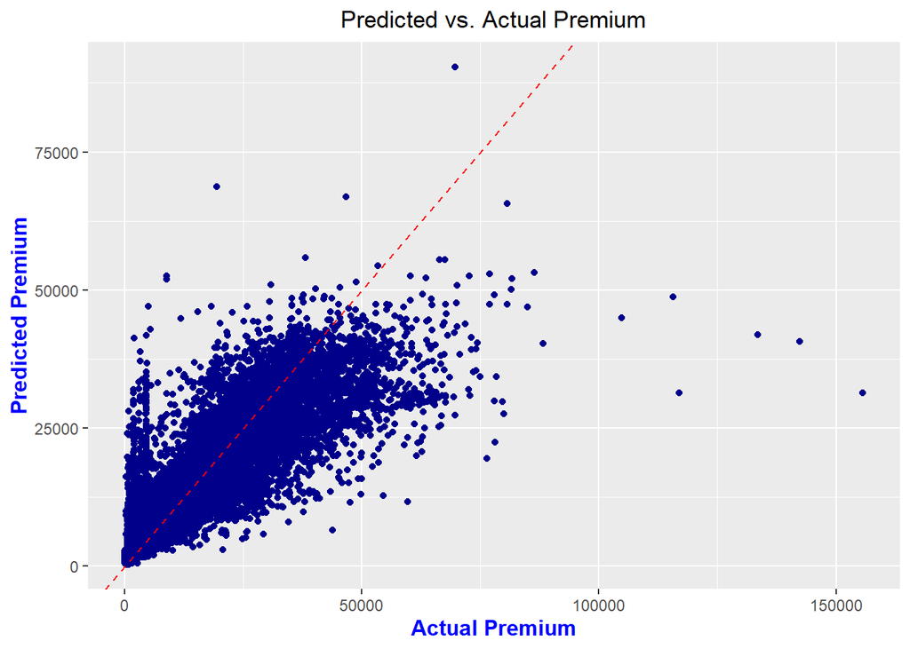

The neural network model was trained to predict the log-transformed premium amount based on the characteristics of the insured vehicles. The model was fitted using the nnet package, with the training data split into 80% training and 20% testing sets. The neural network model was trained with a hidden layer size of 5 neurons, linear output for regression tasks, and a maximum of 100 iterations for training.

### Neural Network Cross Validation

Nevertheless, we cannot be sure that those values for the model above are truly correct or it was luck that the model performs well at a first instance. To solve this question, the NN will be run again using **k-fold Cross Validation** with hyperparameter tuning. This approach will help ensure that the model’s performance is robust and not due to overfitting or random chance. The k-fold Cross Validation will produce a more reliable estimate of the model’s performance by splitting the data into k = 10 subsets, training the model on k-1 subsets, and validating it on the remaining subset. This process is repeated k times, and the results are averaged to provide a comprehensive evaluation of the model.

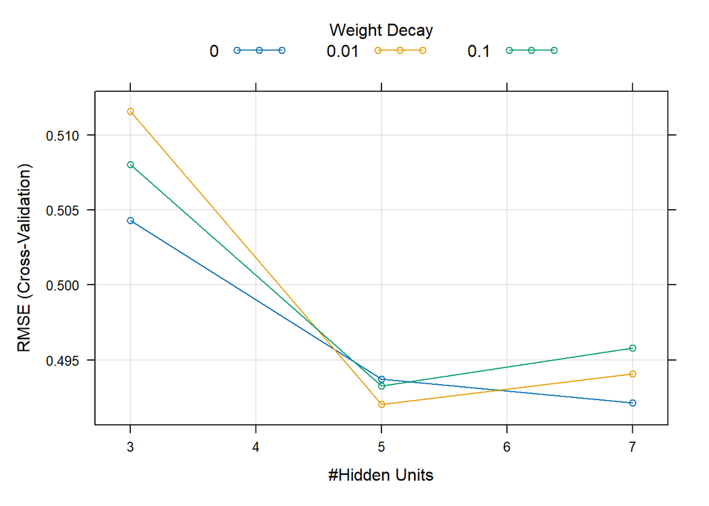

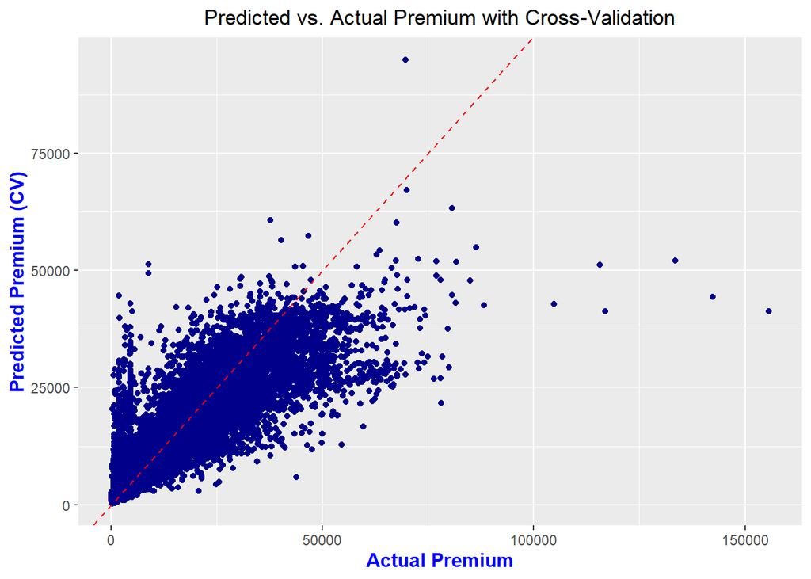

## Results

| Model | Mean Squared Error (MSE) | R-squared | Root Mean Squared Error (RMSE) | Mean Absolute Error (MAE) | Mean Absolute Percentage Error (MAPE) |
| --- | --- | --- | --- | --- | --- |
| Neural Network | 0.2345529 | 0.7510002 | 0.4843067 | 0.3009332 | 3.488952 % |
| Neural Network Cross Validation | 0.2343864 | 0.751177 | 0.4841347 | 0.2981682 | 3.462526 % |

The results from both the neural network and the neural network with cross-validation are very similar, with only minor differences in the evaluation metrics. This consistency suggests that the model is robust and performs well regardless of the validation method used. The cross-validation approach confirms the reliability of the neural network model, indicating that it is not overfitting and generalizes well to unseen data.

The evaluation of the neural network model revealed a Mean Squared Error (MSE) of 0.23, indicating the average squared difference between the actual and predicted log-transformed premium amounts. The R-squared value of 0.75 suggests that the model can explain approximately 75.10% of the variance in the log-transformed premiums, indicating a good fit to the data. The Root Mean Squared Error (RMSE) of 0.48 represents the square root of the MSE, providing a measure of the model’s prediction accuracy. The Mean Absolute Error (MAE) of 0.30 indicates the average absolute difference between the actual and predicted log-transformed premiums. The Mean Absolute Percentage Error (MAPE) of 3.46% represents the average percentage difference between the actual and predicted premiums, providing a measure of the model’s relative accuracy.

Overall, the neural network model demonstrates good performance in predicting the premium amounts based on the characteristics of the insured vehicles and drivers. The model captures the underlying patterns in the data and provides accurate predictions of the premium amounts. The evaluation metrics indicate that the model has a high level of accuracy and predictive power, which could make it a valuable tool for premium prediction in the insurance industry.